# Quantifying Risk for Accelerated Drug Development

Duke Industry Statistical Symposium 2026

Andrew Bean

Advanced Quantitative Sciences, Novartis Pharmaceuticals, East Hanover, NJ

April 10, 2026

# Accelerated Clinical Development Planning

## Accelerated CDPs: context and challenge

**When are accelerated plans considered?**

- Strong clinical rationale (well understood MoA, target)
- Strong unmet need (e.g. rare diseases)
- Strategic considerations (competitive pressure)

**How are CDPs accelerated?**

By bypassing traditional steps:

- Skipping Ph2a PoC $\rightarrow$ straight to Ph2b
- Skipping Ph2b $\rightarrow$ straight from PoC to Ph3
- Skipping Ph2 entirely

**Quantifying risk**

Acceleration entails risk — the key challenge for statisticians is to **quantify and communicate** the level of risk

# Concepts

## Frequentist metrics

In an idealized situation where we evaluate the treatment effect for the same population, endpoints, control arms at each stage …

**Given we are starting stage $x$, what is $P(\text{pass all remaining stages})$?**

We can answer this question only with “if-then” analyses, where the “if” is an assumption about the true treatment effect.

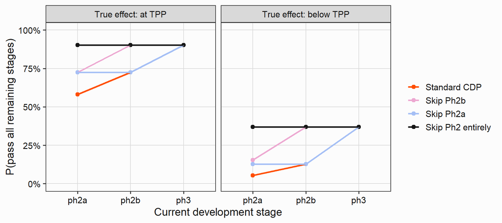

**Shortcoming: how plausible are these scenarios?**

## Bayesian extension

**Allows us to incorporate beliefs and uncertainty about treatment effect through a prior, which (in the idealized situation) can be easily updated as data accumulates**

If we begin (before phase-2) with a uniform prior for the treatment effect (from zero to 150% of the TPP):

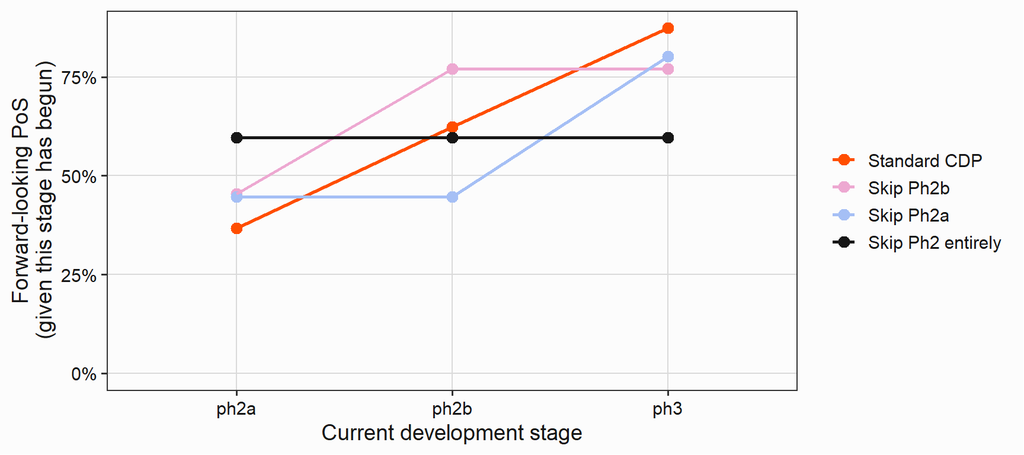

# Example

## Straight to Phase-3: how to evaluate risk?

- **Setting**: Lifecycle management program going **straight to Phase 3** — no separate proof-of-concept study
- **Rationale**: Positive results in adjacent indications; accelerated timelines due to competitive pressure
- **Key risk**: High uncertainty about the treatment effect at the pivotal decision point
- **Risk mitigation**: Two parallel Phase-3 studies will include a **“PoC-like” interim futility analysis**, with a stringent boundary to discharge risk early

**Two key risk metrics for decision makers:**

1. Today: what is the **probability of success (PoS)**, given what we know?
2. Tomorrow: if the program **passes the futility interim**, how much does this increase the PoS estimate?

## PoS today and after futility

$$\text{Assurance} \;=\; \int P\!\Big(\hat\theta_{\text{int}} > c,\;\; \hat\theta_{\text{fin}} \in \mathcal{S} \;\Big|\; \theta\Big) \; \pi(\theta)\; d\theta
\qquad\qquad
\text{Assurance}_{\text{post}} \;=\; \frac{\text{Assurance}}{P\big(\hat\theta_{\text{int}} > c\big)}$$

with $\big(\hat\theta_{\text{int}},\, \hat\theta_{\text{fin}}\big) \mid \theta \;\sim\; \text{BVN}\!\big((\theta, \theta),\; \sigma_{\text{int}} , \sigma_{\text{fin}} , \rho\!\big)$, $\;\rho = \sqrt\tau$, futility boundary $c$, and success region $\mathcal S$.

$$\text{PoS} \;=\; \text{Joint assurance for all Phase-3 trials} \; \times \underbrace{\text{P(approval | all Phase-3 success)}}_{\text{separate assessment}}$$

**Ingredients:**

1. A suitable **prior** $\pi(\theta)$ for the treatment effect — difficult yet crucial when Phase 2 data is absent *(next slide)*
2. Interim and final readouts share patients $\Rightarrow$ **correlated at square root of information fraction**
3. **Monte Carlo evaluation**: draw $\theta^{(m)} \sim \pi(\theta)$, then jointly simulate $\big(\hat\theta_{\text{int}}^{(m)},\, \hat\theta_{\text{fin}}^{(m)}\big)$ from the BVN

**From MC draws to PoS:**

- **PoS today** = fraction of all $M$ draws where interim passes *and* final succeeds, and regulatory approval is obtained
- **PoS post futility** = based on restriction to draws with passed futility — equivalent to $\text{PoS}/P(\text{pass})$ (Dragalin 2026)
- Passage of futility is a **pre-posterior Bayesian update** with a censored observation.

## Calibrated benchmark priors

**Problem:** Before we’ve seen Phase-2 data — what prior should we use for the treatment effect?

**Idea** Hampson et al. (2022): Build a two-component mixture prior :

1. **Null component** centered at zero (no effect)
2. **TPP component** centered at the TPP

**Calibration:** choose the mixture weight $w$ so that the **prior-predictive probability of a program succeeding** across a standardized series of remaining trials **matches the industry-wide historical success rate** for similar programs.

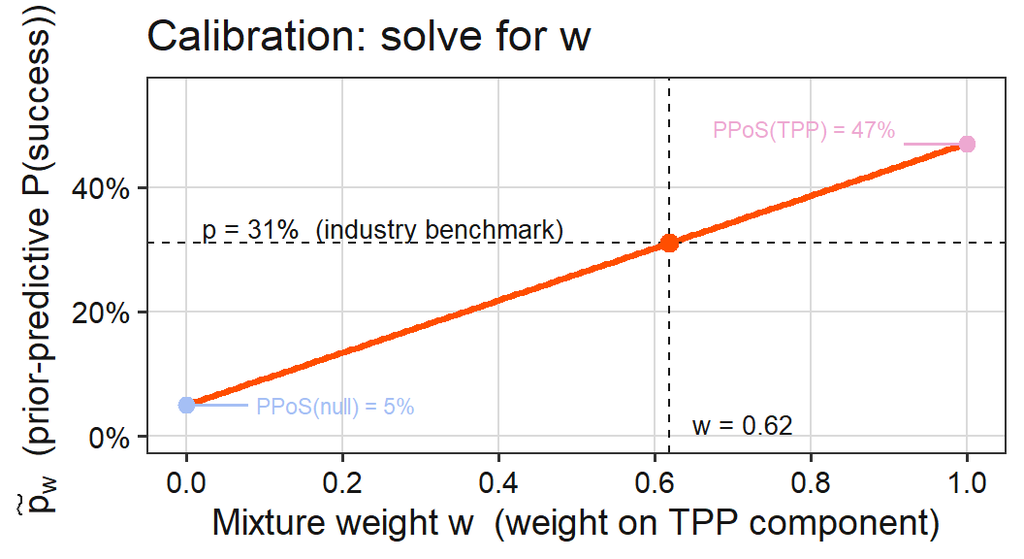

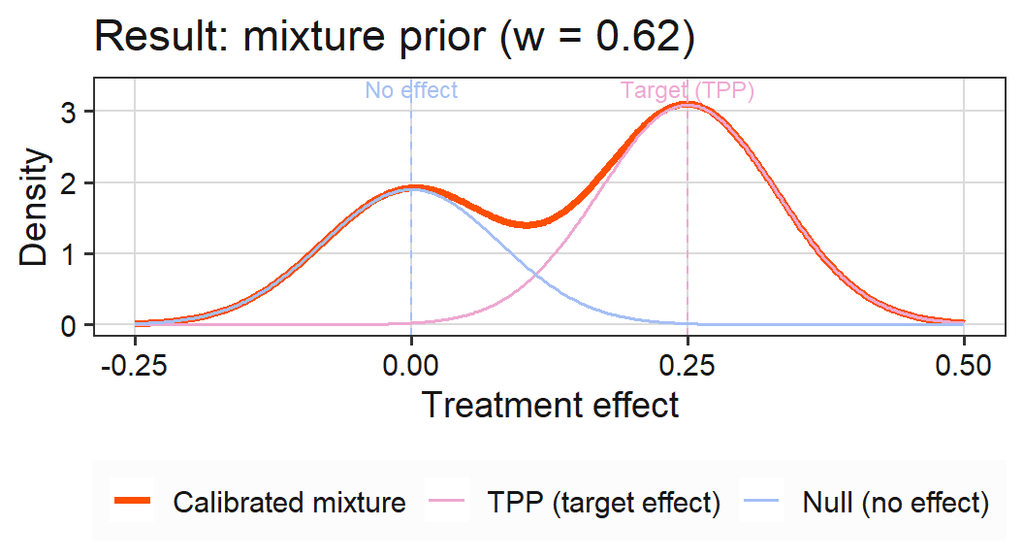

## Result for the example project

[interactive chart not shown]

**How much does the futility analysis de-risk? Try adjusting the design:**

[interactive chart not shown]

## The fundamental trade-off

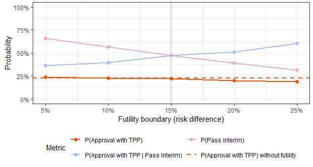

More stringent futility boundaries **lower PoS today** (“PoS loss”), but they raise conditional PoS (greater de-risking).

- **Stricter boundary** $\rightarrow$ more risk discharged if the program continues, but more PoS lost overall
- **Quantifying this trade-off** is the core contribution, to create transparency for decision makers

# Value optimization

## The natural extension: eNPV

```
%%{init: {'theme': 'base', 'themeVariables': {'primaryColor': '#f5f5f5', 'primaryTextColor': '#161616', 'primaryBorderColor': '#dadada', 'lineColor': '#161616', 'secondaryColor': '#dadada', 'tertiaryColor': '#fcfcfc', 'fontFamily': 'system-ui, sans-serif'}}}%%
flowchart LR
  A["Start Ph3<br/>Cost C₁"] --> B{"Pass futility?"}
  B -- "Yes · P(pass)" --> C["Continue<br/>Cost C₂"]
  B -- "No · 1−P(pass)" --> D["Stop early<br/>Save C₂ + C₃"]
  C --> E{"Final success?"}
  E -- "Yes · P(pivotal success|pass)" --> F["Submit<br/>Cost C₃"]
  E -- "No" --> G["Write-off<br/>C₁ + C₂"]
  F --> H{"Approved?"}
  H -- "Yes · P(approval|pivotal success)" --> I["Revenue V"]
  H -- "No" --> J["No approval<br/>Write-off C₁ + C₃"]
```

- **eNPV** is an expectation of costs and revenue over this probability tree
- Futility affects eNPV through **two channels**: cost savings from early stopping *and* reduced probability of reaching revenue
- The **same simulation framework** that produces conditional PoS provides all stagewise inputs to eNPV

# Takeaways

## Key messages

#### Methodological

1. **Conditional assurance** is the natural prospective metric for futility-gated programs — it handles uncertainty about $\theta$ without unblinding
2. The **benchmark-calibrated prior** is a principled fallback when Phase 2 data is absent; data sharpens it when available
3. For straight-to-phase-3 accelerations with stringent de-risking via futility rules: **joint simulation** approach (BVN with $\rho = \sqrt\tau$) provides a complete picture: P(pass), conditional PoS, and overall PoS in a single framework

#### Practical

4. **No single metric suffices for communicating about risk** — but PoS is central because it feeds both expectations and portfolio valuation
5. **Transparent quantification of trade-offs** (PoS loss vs. risk discharged) enables informed design decisions across diverse stakeholders

## Acknowledgements

- Zhenwei Yang
- Francesca Gasperoni
- Jennifer Ng
- Markus Lange
- Björn Holzhauer
- Joseph Kahn
- Alex Przybylski
- David Ohlssen
- Nirav Ratia
- Andrew Wright
- Robert Grant
- Steffen Ballerstedt
- Insa Sommer
- Juergen Ruth

## References

Dragalin, Vladimir. 2026. “Informative Futility Rules Based on Conditional Assurance.” *Statistics in Medicine* 45 (1-2): e70330. https://doi.org/https://doi.org/10.1002/sim.70330.

Hampson, Lisa V., Björn Bornkamp, Björn Holzhauer, Joseph Kahn, Markus R. Lange, Wen-Lin Luo, Giovanni Della Cioppa, Kelvin Stott, and Steffen Ballerstedt. 2022. “Improving the Assessment of the Probability of Success in Late Stage Drug Development.” *Pharmaceutical Statistics* 21 (2): 439–59. https://doi.org/https://doi.org/10.1002/pst.2179.